# sample-criteria

Sun JingWen

2024-09-16

```r
library(sample.criteria)
```

# Background

Clinical prediction models (CPMs) are often developed using logistic regression to predict binary health outcomes. However, they can also be developed using multinomial logistic regression for outcomes with multiple levels, such as cancer grade or Likert scales. Multinomial models have been effective in various clinical settings, and some argue that they should be used more often. It’s important to ensure the sample size of the development dataset is adequate to minimize overfitting and provide precise predictions. Pate et al. (2023) proposes to extend the existing sample criteria defined by Riley et al. (2020).

# Introduction

Ensor (2018) wrote a package for calculating the sample criteria based on the implementation in Stata. The package `sample.criteria` basically extends the current framework of binary logistic regression models into multinomial ones for determining the minimum sample size required when developing a prediction model. However,calculating these different criteria are dependent on the information reported by the model.

- Riley et al. (2019) uses event outcomes;
- Riley, Van Calster, and Collins (2021) uses a prevalance and a C-statistics;
- Pate et al. (2023) uses prevalances and pairwise C-statistics.

In this vignette, we’ll explore how `pmsampsize()` function deals the situation properly.

## Installation

You can install the `sample.criteria` package from Github using the following command:

```r
# remotes::install_github("jingwen517/sample-criteria")
# library(sample.criteria)
```

# Usage

## Case Study: Tumor Type Prediction

This package has two main functions: **pmsamplesize()** and **approximate_R2()**. We will mainly focus on the example in Pate et al. (2023, 564).

The very least information a user needs to provide is event outcomes or prevalance to further calculate the $R^2_{CS,adj,k,r}$ required by sample criteron 1 and $\texttt{max}(R^2_{CS,app})$ required by criterion 2. **Note** that criterion 1 is sensitive to this and tends to return a higher predicted sample size if a rounded prevalance is given to the `p` argument in `pmsamplesize()` function compared to just event outcomes. The following is a flowchart of $R^2_{CS,adj,k,r}$ derivation:

https://raw.githubusercontent.com/chuckleong21/sample-criteria/main/vignettes/r2_derivation.png

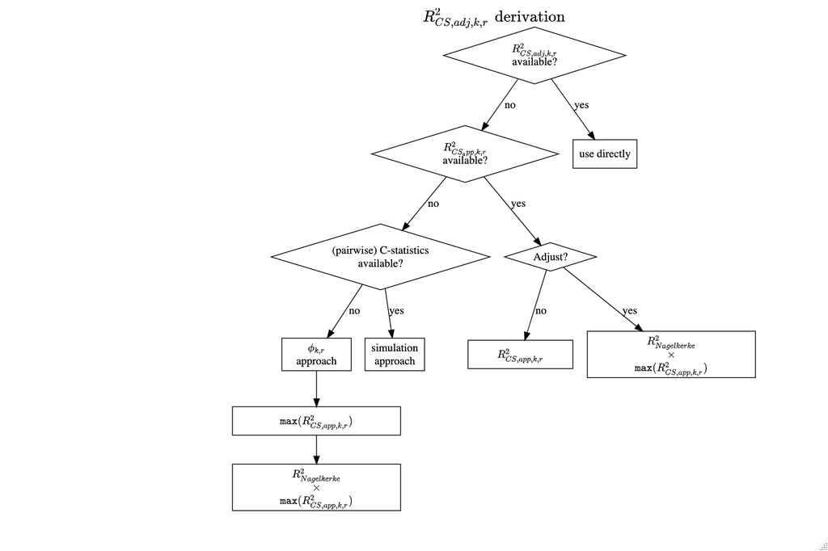

### Case 1: Only C statistics is reported

In clinical studies, Cox-Snell $R^2$ often has the following issues:

- The Cox-Snell R-squared is often criticized for its lack of interpretability and its sensitivity to censoring (when some event times are unknown due to follow-up truncation).
- It does not consider the actual distribution of survival times or the shape of the hazard function.
- Additionally, it assumes that the proportional hazards assumption holds, which may not always be the case.

We can then appropriate $R^2_{CS}$ using the C statistics and event prevalence (outcome proportion). The steps are detailed in [Github](https://github.com/alexpate30/MRC-multi-outcome/blob/394a236a83df524074197d9dc194fdafe96aad9c/Project%208%20Multinomial%20Sample%20Size/code/p3.1%20worked%20example.R#L142). We can execute the simulation with the following command:

```r
set.seed(101)
mapply(approximate_R2,
       k = 5,
       auc = c(0.85, 0.92, 0.99, 0.95, 0.75, 0.95, 0.87, 0.87, 0.71, 0.82),
       prev = c(0.729, 0.053, 0.05, 0.133, 0.034))
```

```
#>  [1] 0.29439854 0.15435216 0.26227726 0.35219081 0.02858901 0.49086766
#>  [7] 0.10912363 0.10410317 0.06626235 0.05093480
```

Here, the $R^2_{CS}$ can be directly used for calculating sample criteria since it is gotten from another dataset. `adjust = TRUE` argument in `pmsamplesize` allows a user to use $R^2_{CS,adj}$ adjusted to amount of $R^2_{Nagelkerke}$. Assuming the new model aimed to consider up to 17 predictor parameters, applying the sample size criteria of Riley et al. Using pmsamplesize() then we should have a minimum sample size of 13135:

```r
set.seed(101)
scriteria <- pmsamplesize(Q = 17,
                          k = 5,
                          p = c(0.729, 0.053, 0.05, 0.133, 0.034),
                          auc = c(0.85, 0.92, 0.99, 0.95, 0.75, 0.95, 0.87, 0.87, 0.71, 0.82))
scriteria
```

```
#> NB: Assuming 0.05 acceptable difference in apparent & adjusted R-squared
#> NB: Assuming 0.05 margin of error in estimation of intercept
#>            sample_size shrinkage parameter    CS_Rsq   Max_Rsq Nag_Rsq
#> Criteria 1       13135      0.90        17 0.1261382 0.8409213    0.15
#> Criteria 2        1478      0.75        17 0.1261382 0.8409213    0.15
#> Criteria 3         525      0.90        17 0.1261382 0.8409213    0.15
#> Final            13135      0.90        17 0.1261382 0.8409213    0.15
```

### Case 2: When Neither Cox-Snell $R^2$ or C-statistics are reported

Pate et al. (2023, 563) recommends derive $R^2_{CS,adj,k,r}$ by the approach suggested by Riley et al. (2020). (Referred as $\varphi_{k,r}$ approach in figure above) In the literature, $\varphi_{k,r}=\frac{E_k}{E_k+E_r}$ is defined as outcome proportion in the category k relative to the reference category r. Then for each distinct logistic regression model $\texttt{max}(R^2_{CS,app,k,r})$ can be calculated as:
$$\texttt{max}(R^2_{CS,app,k,r})=1-\varphi_{k,r}^{(\varphi_{k,r}}(1-\varphi_{k,r})^{1-\varphi_{k,r}})^2$$
If a multinomial model had been published, then this information would be available for each distinct logistic regression model assuming the number of events in each category had been reported. $R^2_{CS,adj,k,r}$ calculated in this approach tends to be smaller and it results to larger sample size. To remedy this issue, the recommendations are put forward in Pate et al. (2023, 564).

```r
bcriteria <- pmsamplesize(Q = 17,
                  k = 5,
                  p = c(2557, 186, 176, 467, 120),
                  r2_nagelkerke = 0.15,
                  shrinkage = 0.9)
bcriteria
```

```
#> NB: Assuming 0.05 acceptable difference in apparent & adjusted R-squared
#> NB: Assuming 0.05 margin of error in estimation of intercept
#>            sample_size shrinkage parameter    CS_Rsq   Max_Rsq Nag_Rsq
#> Criteria 1       15280      0.90        17 0.1261869 0.8412462    0.15
#> Criteria 2        1477      0.75        17 0.1261869 0.8412462    0.15
#> Criteria 3         524      0.90        17 0.1261869 0.8412462    0.15
#> Final            15280      0.90        17 0.1261869 0.8412462    0.15
```

By default, the first element in the vector is the $Y=0$ group (benign) group. `p` argument will be properly handled by the function, be it proportion outcomes or event outcomes.

### Case 3: Cohort Cox-Snell $R^2_{CS\_adj,k,r}$ approximation with C statistics

To calculate the criterion 1 minimum sample size, we need the cohort $R^2_{CS\_adj,k,r}$ information, which sometimes are not reported in studies. We can the approximate them using the simulation approach put forward by Riley et al. Estimates of the pairwise outcome proportions $\varphi_{k,r}$ of category k relative to the reference category r are also required to implement the simulation approach. One can supply the $\phi_{k,r}$ value to argument , but it could also be left blank and the calculation will be done internally with argument `p`. The example in Pate et al. (2023, 565) could be executed with the following demand:

```r
set.seed(101)
acriteria <- pmsamplesize(Q = 17,
                  k = 5,
                  p = c(2557, 186, 176, 467, 120),
                  r2_nagelkerke = 0.15,
                  shrinkage = 0.9,
                  auc = c(0.85, 0.92, 0.99, 0.95, 0.75, 0.95, 0.87, 0.87, 0.71, 0.82))
acriteria
```

```
#> NB: Assuming 0.05 acceptable difference in apparent & adjusted R-squared
#> NB: Assuming 0.05 margin of error in estimation of intercept
#>            sample_size shrinkage parameter    CS_Rsq   Max_Rsq Nag_Rsq
#> Criteria 1       13063      0.90        17 0.1261869 0.8412462    0.15
#> Criteria 2        1477      0.75        17 0.1261869 0.8412462    0.15
#> Criteria 3         524      0.90        17 0.1261869 0.8412462    0.15
#> Final            13063      0.90        17 0.1261869 0.8412462    0.15
```

# Conclusion

Through the illustrations above, package can easily calculate pre-defined sample criteria for future modelling given what kind of information is reported in various studies.

# References

Ensor, Joie. 2018. “PMSAMPSIZE: Stata module to calculate the minimum sample size required for developing a multivariable prediction model.” Statistical Software Components, Boston College Department of Economics. https://ideas.repec.org/c/boc/bocode/s458569.html.

Pate, Alexander, Richard D Riley, Gary S Collins, Maarten van Smeden, Ben Van Calster, Joie Ensor, and Glen P Martin. 2023. “Minimum Sample Size for Developing a Multivariable Prediction Model Using Multinomial Logistic Regression.” *Stat. Methods Med. Res.* 32 (3): 555–71.

Riley, Richard D, Joie Ensor, Kym I E Snell, Frank E Harrell, Glen P Martin, Johannes B Reitsma, Karel G M Moons, Gary Collins, and Maarten van Smeden. 2020. “Calculating the Sample Size Required for Developing a Clinical Prediction Model.” *BMJ* 368. https://doi.org/10.1136/bmj.m441.

Riley, Richard D, Kym Ie Snell, Joie Ensor, Danielle L Burke, Frank E Harrell Jr, Karel Gm Moons, and Gary S Collins. 2019. “Minimum Sample Size for Developing a Multivariable Prediction Model: PART II - Binary and Time-to-Event Outcomes.” *Stat. Med.* 38 (7): 1276–96.

Riley, Richard D, Ben Van Calster, and Gary S Collins. 2021. “A Note on Estimating the Cox-Snell R2 from a Reported C Statistic (AUROC) to Inform Sample Size Calculations for Developing a Prediction Model with a Binary Outcome.” *Stat. Med.* 40 (4): 859–64.